# RALLI_FT

2023-10-09

*ELENI RALLI*

*A.M. : f2822312*

## Assigment 1

### 1) Load the data in an object named dataLogistics. (0.5 point)

```r
dataLogistics<-read.table("C:\\Users\\eleni\\Downloads\\Logistics.txt", header=TRUE, sep= ",")
```

to see my data and see if it was read correctly :

```r
str(dataLogistics)
```

```
## 'data.frame':    2279 obs. of  8 variables:
##  $ id             : int  1 2 3 4 5 6 7 8 9 10 ...
##  $ unit_price     : num  0.058 0.954 2.385 5.1 0 ...
##  $ expire_date    : int  547 547 547 547 547 547 547 547 547 365 ...
##  $ outbound_number: int  9 0 12 0 0 1 2 0 0 0 ...
##  $ total_outbound : num  2441 0 23 0 0 ...
##  $ pal_weight     : num  106 208 166 221 0 ...
##  $ pal_height     : num  1.56 1 1.02 1.05 0 1 1.02 0 0 1.44 ...
##  $ units_per_pal  : int  1920 384 108 72 0 384 108 0 0 36 ...
```

```r
length(dataLogistics)
```

```
## [1] 8
```

```r
dim(dataLogistics)
```

```
## [1] 2279    8
```

```r
head(dataLogistics)
```

```
##   id unit_price expire_date outbound_number total_outbound pal_weight
## 1  1      0.058         547               9           2441     105.60
## 2  2      0.954         547               0              0     207.68
## 3  3      2.385         547              12             23     165.78
## 4  4      5.100         547               0              0     221.04
## 5  5      0.000         547               0              0       0.00
## 6  6      1.110         547               1              1     207.68
##   pal_height units_per_pal
## 1       1.56          1920
## 2       1.00           384
## 3       1.02           108
## 4       1.05            72
## 5       0.00             0
## 6       1.00           384
```

```r
tail(dataLogistics)
```

```
##        id unit_price expire_date outbound_number total_outbound pal_weight
## 2274 2274          0           0               0              0       2.70
## 2275 2275          0           0               0              0       2.70
## 2276 2276          0           0               1              1       9.58
## 2277 2277          0           0               0              0      38.36
## 2278 2278          0           0               1              1      25.11
## 2279 2279          0         547              76           1570     105.60
##      pal_height units_per_pal
## 2274          0            10
## 2275          0            10
## 2276          0             1
## 2277          0             4
## 2278          0             3
## 2279          0          1920
```

### 2) Check for any missing values in dataLogistics. If any are found, then delete those observations. How many observations have been deleted? (0.5 point)

```r
is.na(dataLogistics)   #we check for missing values
```

```r
head(is.na(dataLogistics)) #  I don't want it to print the whole data.frame, I just want to see its format, so i check only the top rows
```

```
##         id unit_price expire_date outbound_number total_outbound pal_weight
## [1,] FALSE      FALSE       FALSE           FALSE          FALSE      FALSE
## [2,] FALSE      FALSE       FALSE           FALSE          FALSE      FALSE
## [3,] FALSE      FALSE       FALSE           FALSE          FALSE      FALSE
## [4,] FALSE      FALSE       FALSE           FALSE          FALSE      FALSE
## [5,] FALSE      FALSE       FALSE           FALSE          FALSE      FALSE
## [6,] FALSE      FALSE       FALSE           FALSE          FALSE      FALSE
##      pal_height units_per_pal
## [1,]      FALSE         FALSE
## [2,]      FALSE         FALSE
## [3,]      FALSE         FALSE
## [4,]      FALSE         FALSE
## [5,]      FALSE         FALSE
## [6,]      FALSE         FALSE
```

```r
sum(is.na(dataLogistics)) # the number of missing values we want to delete
```

```
## [1] 5
```

```r
which(is.na(dataLogistics)) # it gives you the index of missing values
```

```
## [1] 4648 4649 4650 4651 4652
```

```r
dataLogistics<-na.omit(dataLogistics) # I assign to my data.frame the dataLogistics that does not contain the missing values
sum(is.na(dataLogistics))  #ΟΚ ,it gives result 0 so i deleted them successfully
```

```
## [1] 0
```

```r
str(dataLogistics) # OK, some comments were deleted if you see the number of them now
```

```
## 'data.frame':    2274 obs. of  8 variables:
##  $ id             : int  1 2 3 4 5 6 7 8 9 10 ...
##  $ unit_price     : num  0.058 0.954 2.385 5.1 0 ...
##  $ expire_date    : int  547 547 547 547 547 547 547 547 547 365 ...
##  $ outbound_number: int  9 0 12 0 0 1 2 0 0 0 ...
##  $ total_outbound : num  2441 0 23 0 0 ...
##  $ pal_weight     : num  106 208 166 221 0 ...
##  $ pal_height     : num  1.56 1 1.02 1.05 0 1 1.02 0 0 1.44 ...
##  $ units_per_pal  : int  1920 384 108 72 0 384 108 0 0 36 ...
##  - attr(*, "na.action")= 'omit' Named int [1:5] 90 91 92 93 94
##   ..- attr(*, "names")= chr [1:5] "90" "91" "92" "93" ...
```

### 3) For which unit the corresponding fully-loaded pallet is the heaviest one? For how many units the corresponding fully-loaded pallets are the shortest ones? Hint: function which(). (0.5 point)

for which—>id

fully-loaded pallet is the heaviest(max) one —>pal_weight

fully-loaded pallets are the shortest(min)ones—>pal_height

```r
max(dataLogistics$pal_weight) # this is the largest size
```

```
## [1] 907.2
```

```r
which(dataLogistics$pal_weight==max(dataLogistics$pal_weight) ) # returns the index of the heaviest
```

```
## [1] 1248
```

```r
dataLogistics$id[which(dataLogistics$pal_weight==max(dataLogistics$pal_weight) )] # it returns the id of the heaviest one
```

```
## [1] 1253
```

```r
dataLogistics[dataLogistics$id==1253,,] #ΟΚ, indeed this is it
```

```
##        id unit_price expire_date outbound_number total_outbound pal_weight
## 1253 1253       0.19         547              33            990      907.2
##      pal_height units_per_pal
## 1253      0.495          2025
```

So, the heaviest fully-loaded pallet has weight =907.2 and there is in the index(position) 1248 , also the id of the unit is 1253

we can do it a little more clearly with sorting to data.frame, this is done with the order command:

```r
order(dataLogistics$pal_weight) # if you give this command, it returns the indexes, e.g. it tells you the smallest is on line 5 position , if you see it, it is actually 0.00 weight
```

```r
dataLogistics3<-dataLogistics[  order(dataLogistics$pal_weight)  ,   ] # the other variables are sorted with it correctly
tail(dataLogistics3) # the element you want is on the last line
```

```
##        id unit_price expire_date outbound_number total_outbound pal_weight
## 1716 1716    24.5020         365             305            505      730.8
## 1273 1273     0.5900         547              98            500      777.6
## 670   670     0.0137           0              92           1835      800.0
## 965   965     0.0000           0               0              0      800.0
## 2207 2207     0.0000           0               2            160      800.0
## 1253 1253     0.1900         547              33            990      907.2
##      pal_height units_per_pal
## 1716      1.800            36
## 1273      0.400          1440
## 670       0.000        200000
## 965       1.200          2500
## 2207      0.000        200000
## 1253      0.495          2025
```

```r
last_row<-dataLogistics3[ nrow(dataLogistics3), ]
last_row
```

```
##        id unit_price expire_date outbound_number total_outbound pal_weight
## 1253 1253       0.19         547              33            990      907.2
##      pal_height units_per_pal
## 1253      0.495          2025
```

```r
#--------------------------------------------------------------------------------------------------
min(dataLogistics$pal_height)
```

```
## [1] 0
```

```r
which(dataLogistics$pal_height==min(dataLogistics$pal_height)) # it returns the index of the shortest one, but here we have many that are equal to 0.00 so it returns a vector (returns the index of all of them)
```

```r
sum(dataLogistics$pal_height==0) #so their crowd is this
```

```
## [1] 782
```

```r
#however each pallet has many units in it so we will need to do an addition to see the answer to "For how many units the corresponding fully-loaded pallets are the shortest ones"

x3<-dataLogistics[which(dataLogistics$pal_height==min(dataLogistics$pal_height)),]
sum(x3$units_per_pal)
```

```
## [1] 943902
```

The corresponding fully-loaded pallets are the shortest ones for 943902 units

### 4) Produce a boxplot of the pal weight variable, for (faceted by) each value of the variable expire data observed in the dataset (in the same plot window). Draw a horizontal line at y=200. (1 point)

```r
colors() #with this vector I will see some predefined colors that R has and choose one
```

the boxplot used for quantitative variables shows upper and lower bounds, the box shows the first and third quartiles and the line in the middle the median. also with dots the extreme values are shown if they exist. the tilde symbol (~), this symbol indicates that the “aspect” - the grouping is based on the variable that comes after it

```r
table(dataLogistics$expire_date) # we see that this variable has 6 categories
```

```
##
##    0  365  456  547  730  734
##  530  305    8 1244  186    1
```

```r
length (table(dataLogistics$expire_date)) # 6 categories
```

```
## [1] 6
```

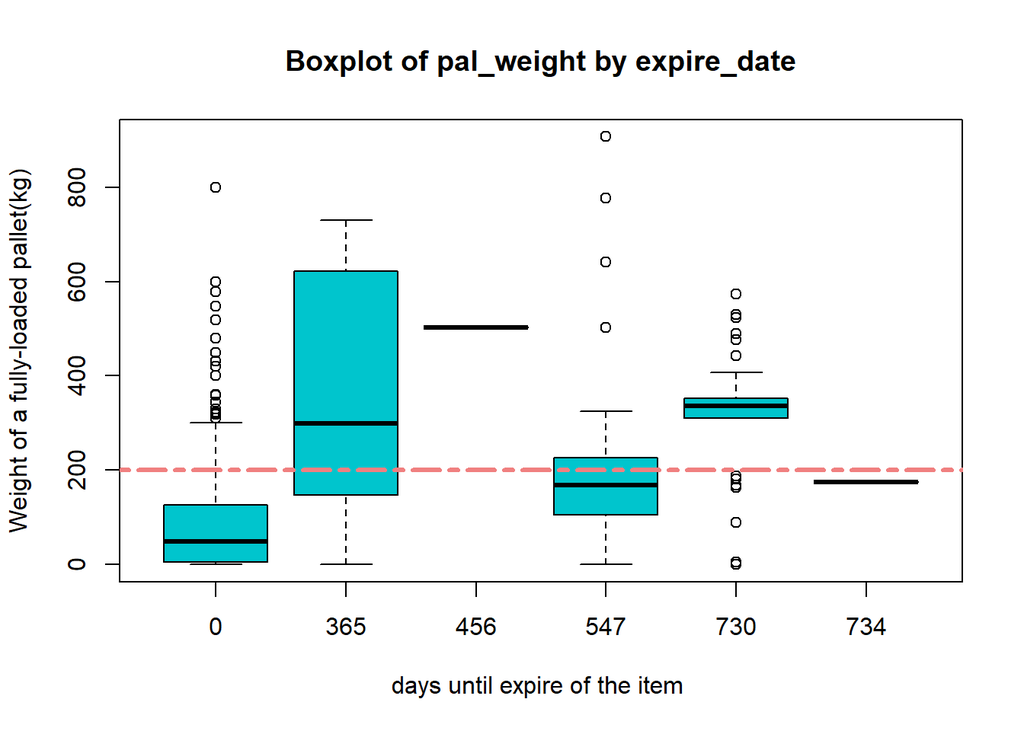

```r
boxplot(dataLogistics$pal_weight~dataLogistics$expire_date,
        main ="Boxplot of pal_weight by expire_date",
        xlab = "days until expire of the item ", ylab = "Weight of a fully-loaded pallet(kg)",
        col="turquoise3")


# Draw a horizontal line at y=200
abline(h = 200, col = "lightcoral" , lty = 6, lwd = 3) #lwd specifies the line weight, lty the line style
```

### 5)Calculate the total amount of money earned (in Euro) from the units sold at prices greater than 0. (1 point)

unit_price –>Unit price in Euro

total_outbound –>Number of pallets sold from 2017-02-06 to 2018-02-13

units_per_pal–> Number of units in a pallet

Steps :

1. I will keep all products that cost > 0 euro, based on the variable unit_price
2. and then I will go from what I have left to multiply how many units_per_pal I have with the corresponding data from total_outbound.

That is:

total_outbound * units_per_pal Number of units in a pallet = how many units I have sold in total from each category of units

3. how many units have I sold in total from each unit category *Unit price in Euro
4. and then I will add up the whole amount.

```r
head(dataLogistics)
```

```
##   id unit_price expire_date outbound_number total_outbound pal_weight
## 1  1      0.058         547               9           2441     105.60
## 2  2      0.954         547               0              0     207.68
## 3  3      2.385         547              12             23     165.78
## 4  4      5.100         547               0              0     221.04
## 5  5      0.000         547               0              0       0.00
## 6  6      1.110         547               1              1     207.68
##   pal_height units_per_pal
## 1       1.56          1920
## 2       1.00           384
## 3       1.02           108
## 4       1.05            72
## 5       0.00             0
## 6       1.00           384
```

```r
attach(dataLogistics) # so I don't have to keep giving the $ sign I'll use this command


data5<-data.frame(cbind(id,unit_price,total_outbound,units_per_pal)) #make a data.frame with what I will use
head(data5)
```

```
##   id unit_price total_outbound units_per_pal
## 1  1      0.058           2441          1920
## 2  2      0.954              0           384
## 3  3      2.385             23           108
## 4  4      5.100              0            72
## 5  5      0.000              0             0
## 6  6      1.110              1           384
```

```r
str(data5)
```

```
## 'data.frame':    2274 obs. of  4 variables:
##  $ id            : num  1 2 3 4 5 6 7 8 9 10 ...
##  $ unit_price    : num  0.058 0.954 2.385 5.1 0 ...
##  $ total_outbound: num  2441 0 23 0 0 ...
##  $ units_per_pal : num  1920 384 108 72 0 384 108 0 0 36 ...
```

```r
#a)
table( data5$unit_price)  # I see that I have 706 units with a value of 0
```

```r
data5_1<-data5[data5$unit_price>0,] # I will exclude these 706 items
str(data5_1) # οκ
```

```
## 'data.frame':    1568 obs. of  4 variables:
##  $ id            : num  1 2 3 4 6 7 9 10 11 12 ...
##  $ unit_price    : num  0.058 0.954 2.385 5.1 1.11 ...
##  $ total_outbound: num  2441 0 23 0 1 ...
##  $ units_per_pal : num  1920 384 108 72 384 108 0 36 72 384 ...
```

```r
table(data5_1$unit_price) # to see the frequency table and to see that I don't have 0,000 values in it, so everything is ok
```

```r
#β)
units_sold<-data5_1$total_outbound*data5_1$units_per_pal
data5_1$units_sold<-units_sold    #now I can paste this column-vector into data5_1
head(data5_1)  # ok
```

```
##   id unit_price total_outbound units_per_pal units_sold
## 1  1      0.058           2441          1920    4686720
## 2  2      0.954              0           384          0
## 3  3      2.385             23           108       2484
## 4  4      5.100              0            72          0
## 6  6      1.110              1           384        384
## 7  7      2.515              4           108        432
```

```r
#γ)
money_earned_per_unit_category <-data5_1$units_sold *data5_1$unit_price
data5_1$money_earned_per_unit_category <-money_earned_per_unit_category #now I can paste this column-vector into data5_1
head(data5_1)  #ok
```

```
##   id unit_price total_outbound units_per_pal units_sold
## 1  1      0.058           2441          1920    4686720
## 2  2      0.954              0           384          0
## 3  3      2.385             23           108       2484
## 4  4      5.100              0            72          0
## 6  6      1.110              1           384        384
## 7  7      2.515              4           108        432
##   money_earned_per_unit_category
## 1                      271829.76
## 2                           0.00
## 3                        5924.34
## 4                           0.00
## 6                         426.24
## 7                        1086.48
```

```r
#δ)
sum(data5_1$money_earned_per_unit_category )
```

```
## [1] 640739266
```

So , the total amount is 640739266

### 6)Find the lightest unit among those for which both the number of the units in the pallet and the weight of the pallet are greater than 0. Hint: function which(). (1 point)

pal_weight—>Weight of a fully-loaded pallet units_per_pal–>Number of units in a pallet

we have the weight of each pallet and the number of units each pallet contains so if we assume that each unit has the same weight, the weight that will correspond to each in each unit will be pal weight/units per pal= unit weight so then I will find from this variable which is the lightest

```r
#first I'll keep what's greater than 0
table(pal_weight) # I see it has 366 elements equal to 0
table (units_per_pal) # I see it has 290 elements equal to 0
```

```r
data6<-dataLogistics[(pal_weight>0) & (units_per_pal>0) ,]

table(data6$pal_weight)  #ok
table(data6$units_per_pal) #ok
```

```r
head (data6)
```

```
##   id unit_price expire_date outbound_number total_outbound pal_weight
## 1  1      0.058         547               9           2441     105.60
## 2  2      0.954         547               0              0     207.68
## 3  3      2.385         547              12             23     165.78
## 4  4      5.100         547               0              0     221.04
## 6  6      1.110         547               1              1     207.68
## 7  7      2.515         547               2              4     165.78
##   pal_height units_per_pal
## 1       1.56          1920
## 2       1.00           384
## 3       1.02           108
## 4       1.05            72
## 6       1.00           384
## 7       1.02           108
```

```r
tail( data6)
```

```
##        id unit_price expire_date outbound_number total_outbound pal_weight
## 2274 2274          0           0               0              0       2.70
## 2275 2275          0           0               0              0       2.70
## 2276 2276          0           0               1              1       9.58
## 2277 2277          0           0               0              0      38.36
## 2278 2278          0           0               1              1      25.11
## 2279 2279          0         547              76           1570     105.60
##      pal_height units_per_pal
## 2274          0            10
## 2275          0            10
## 2276          0             1
## 2277          0             4
## 2278          0             3
## 2279          0          1920
```

```r
unit_weight <-data6$pal_weight/data6$units_per_pal #now I will divide pal weight/units per pal= unit_weight


data6$unit_weight<-unit_weight # i will paste  this vector-column  to data6
head(data6)
```

```
##   id unit_price expire_date outbound_number total_outbound pal_weight
## 1  1      0.058         547               9           2441     105.60
## 2  2      0.954         547               0              0     207.68
## 3  3      2.385         547              12             23     165.78
## 4  4      5.100         547               0              0     221.04
## 6  6      1.110         547               1              1     207.68
## 7  7      2.515         547               2              4     165.78
##   pal_height units_per_pal unit_weight
## 1       1.56          1920   0.0550000
## 2       1.00           384   0.5408333
## 3       1.02           108   1.5350000
## 4       1.05            72   3.0700000
## 6       1.00           384   0.5408333
## 7       1.02           108   1.5350000
```

```r
# and I will find which id corresponds to the lightest one
mikrotero_unit_weight<-data6[which(data6$unit_weight==min(data6$unit_weight)), ]
mikrotero_unit_weight   #The number "2e-04" represents the value 0.0002
```

```
##        id unit_price expire_date outbound_number total_outbound pal_weight
## 1015 1015       0.62           0              34            401        1.6
##      pal_height units_per_pal unit_weight
## 1015          0          8000       2e-04
```

```r
erwt_6<-paste("the lightest unit among those for which both the number of the units in the pallet and the weight of the pallet are greater than 0 is the unit with id " ,mikrotero_unit_weight$id,"and its weight is ", mikrotero_unit_weight$unit_weight)
erwt_6
```

```
## [1] "the lightest unit among those for which both the number of the units in the pallet and the weight of the pallet are greater than 0 is the unit with id  1015 and its weight is  2e-04"
```

### 7) Some values in expire date are equal to 0. Create a new data frame, named dataLogistics2, which does not include these observations. In dataLogistics2 data frame, for which unit the corresponding fully-loaded pallet is the heaviest one? (0.5 points)

pal_weight–> Weight of a fully-loaded pallet

id–>ID of the unit

```r
dataLogistics2<-dataLogistics[which(expire_date!=0),]
table(expire_date)
```

```
## expire_date
##    0  365  456  547  730  734
##  530  305    8 1244  186    1
```

```r
table(dataLogistics2$expire_date)  # ok
```

```
##
##  365  456  547  730  734
##  305    8 1244  186    1
```

```r
heaviest_f_load_pallet<-dataLogistics2[ which(dataLogistics2$pal_weight==max(dataLogistics2$pal_weight)) ,  ]
heaviest_f_load_pallet
```

```
##        id unit_price expire_date outbound_number total_outbound pal_weight
## 1253 1253       0.19         547              33            990      907.2
##      pal_height units_per_pal
## 1253      0.495          2025
```

```r
heaviest_f_load_pallet$pal_weight
```

```
## [1] 907.2
```

```r
heaviest_f_load_pallet$id
```

```
## [1] 1253
```

the unit with id 1253

### 8) Work with the dataLogistics2 data frame. Create a matrix with two columns, one with the outbound number variable and one with the total outbound one. Calculate a vector that includes the average of the two, by using the apply() function. (1 point)

```r
data8<-data.frame(cbind(dataLogistics2$outbound_number,dataLogistics2$total_outbound))
head(data8)
```

```
##   X1   X2
## 1  9 2441
## 2  0    0
## 3 12   23
## 4  0    0
## 5  0    0
## 6  1    1
```

```r
colnames(data8)<-c("outbound_number","total_outbound")
head(data8) # ok
```

```
##   outbound_number total_outbound
## 1               9           2441
## 2               0              0
## 3              12             23
## 4               0              0
## 5               0              0
## 6               1              1
```

```r
erwt8<-apply(data8,MARGIN = 2, FUN = mean )  # the average= the mean
erwt8
```

```
## outbound_number  total_outbound
##        304.9891        890.5371
```

```r
ervt8vector<-as.vector(erwt8)
ervt8vector
```

```
## [1] 304.9891 890.5371
```

the number 304.9891 is the average of the outbound_number variable

the number 890.5371 is the average of the total_outbound variable

### 9)Work with the dataLogistics2 data frame. Create a scatterplot with pal weight on the x-axis and pal height on the y-axis. The main title should be “Weight and Height of Pallets” and the axes should be named accordingly.Colour with black the dots for which pal height>1; otherwise, colour them with red.Add a horizontal dashed line for pal height=1. Make the y-axis labels to be perpendicular to the axis. (2 points)

```r
head(dataLogistics2)
```

```
##   id unit_price expire_date outbound_number total_outbound pal_weight
## 1  1      0.058         547               9           2441     105.60
## 2  2      0.954         547               0              0     207.68
## 3  3      2.385         547              12             23     165.78
## 4  4      5.100         547               0              0     221.04
## 5  5      0.000         547               0              0       0.00
## 6  6      1.110         547               1              1     207.68
##   pal_height units_per_pal
## 1       1.56          1920
## 2       1.00           384
## 3       1.02           108
## 4       1.05            72
## 5       0.00             0
## 6       1.00           384
```

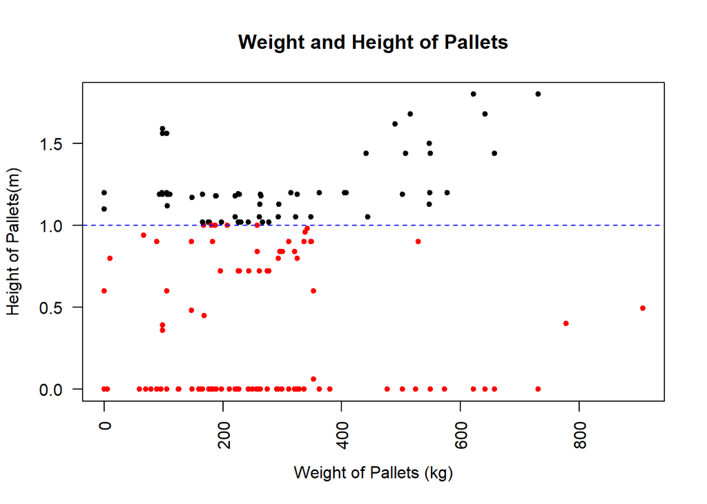

```r
colordot=character(0)# an empty character vector , we will fill it

for (i in dataLogistics2$pal_height) {
  if (i>1)  {
   colordot=c(colordot,"black")
  }else {
    colordot=c(colordot,"red")
  }
}




par(las=2) #Make the y-axis labels to be perpendicular to the axis


plot(dataLogistics2$pal_weight,dataLogistics2$pal_height,
     main = "Weight and Height of Pallets",
     xlab = "Weight of Pallets (kg)",
     ylab = "Height of Pallets(m)",
     col=colordot,
     pch=19, cex = 0.7  ,       #pch I choose a shape and that I want them filled with color, cex I choose their size
     )


abline(h = 1,col= "blue", lty = 2) # lty gives the line type
```

### 10) Create a new variable, named quality, assigned it to the dataLogistics2 data frame. The new variable describes the quality of units. If the price of a unit is greater than 15, then the quality of the unit is Very Good. Otherwise, the quality of the unit is Good. Then, create a grouped barplot of the new variable and the expire date. The main title should be “Quality and Expire Date”. Also, the axes should be named, accordingly providing an appropriate legend at the topright of the grouped barplot. (2 points)

```r
# make a character vector (categorical variable) that for unit_price>15 will get the value "Very Good" and for
#any other value will take the value "Good"

quality<-character(0)   # an empty character vector

for(i in dataLogistics2$unit_price) {
  if(i>15){
   quality=c(quality,"Very Good")
  }else{
   quality=c(quality,"Good")
  }
}

quality<-as.factor(quality)    # make it categorical value

dataLogistics2$quality<-quality # paste it in the data.frame
head(dataLogistics2) #ok
```

```
##   id unit_price expire_date outbound_number total_outbound pal_weight
## 1  1      0.058         547               9           2441     105.60
## 2  2      0.954         547               0              0     207.68
## 3  3      2.385         547              12             23     165.78
## 4  4      5.100         547               0              0     221.04
## 5  5      0.000         547               0              0       0.00
## 6  6      1.110         547               1              1     207.68
##   pal_height units_per_pal quality
## 1       1.56          1920    Good
## 2       1.00           384    Good
## 3       1.02           108    Good
## 4       1.05            72    Good
## 5       0.00             0    Good
## 6       1.00           384    Good
```

```r
str(dataLogistics2)  #ok
```

```
## 'data.frame':    1744 obs. of  9 variables:
##  $ id             : int  1 2 3 4 5 6 7 8 9 10 ...
##  $ unit_price     : num  0.058 0.954 2.385 5.1 0 ...
##  $ expire_date    : int  547 547 547 547 547 547 547 547 547 365 ...
##  $ outbound_number: int  9 0 12 0 0 1 2 0 0 0 ...
##  $ total_outbound : num  2441 0 23 0 0 ...
##  $ pal_weight     : num  106 208 166 221 0 ...
##  $ pal_height     : num  1.56 1 1.02 1.05 0 1 1.02 0 0 1.44 ...
##  $ units_per_pal  : int  1920 384 108 72 0 384 108 0 0 36 ...
##  $ quality        : Factor w/ 2 levels "Good","Very Good": 1 1 1 1 1 1 1 1 1 1 ...
##  - attr(*, "na.action")= 'omit' Named int [1:5] 90 91 92 93 94
##   ..- attr(*, "names")= chr [1:5] "90" "91" "92" "93" ...
```

```r
#to make the barplot, you must first make the frequency table
table(dataLogistics2$expire_date) #ok
```

```
##
##  365  456  547  730  734
##  305    8 1244  186    1
```

```r
table(dataLogistics2$quality) #ok
```

```
##
##      Good Very Good
##      1565       179
```

```r
table10<-table(dataLogistics2$quality,dataLogistics2$expire_date )
```

the prop.table command calculates the proportions of each( default=0) , if you put 1 it calculates the proportions per row while if you put 2 it calculates the proportions per column, if you don’t put anything (0) in the whole table rather.

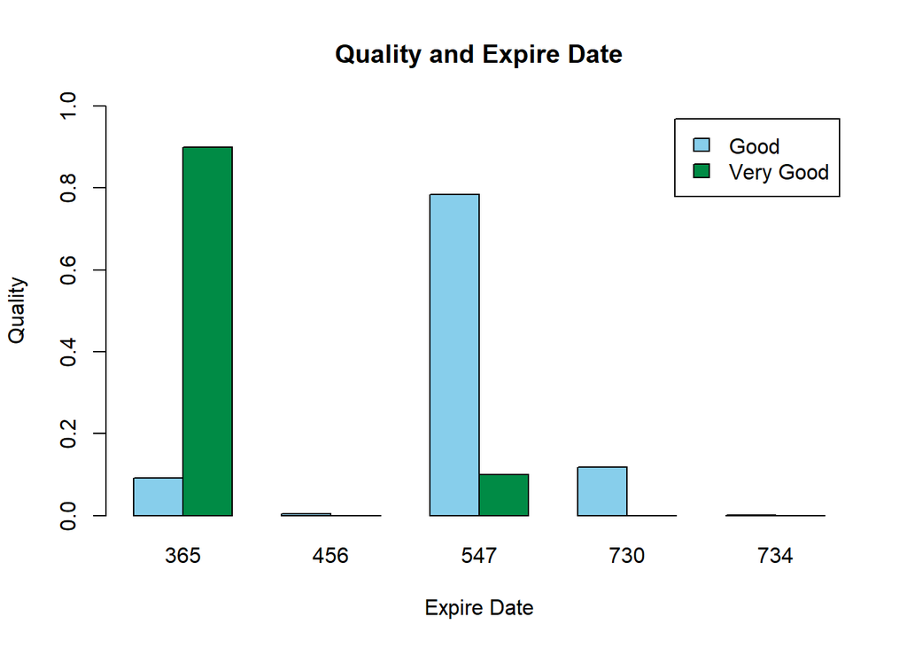

```r
barplot(prop.table(table10,1) ,
        beside = TRUE, # grouped barplot
        width=0.25,   #if you set it equal to a vector you could have a different width on each bar
        main = "Quality and Expire Date",
        xlab = "Expire Date",ylab = "Quality",
        ylim=c(0,1)    ,                                    # xlim & ylim: Range of the axes.
        legend=levels(dataLogistics2$quality),
        col=c("skyblue","springgreen4")
        )
```